# Arctic Sea Ice Analysis v1

Mike Simko

4/24/2018

## Introduction

A dataset of Arctic Sea Ice was found at data.world for a Makeover Monday project [https://data.world/arcticseaice]. It included data (month/day/year) and Extent of the observed Arcitc ice in million square kilometers (mkm2). The dataset was slightly tweaked to decompose the date column into seperate year, month and day columns. An additional column named “diff” (difference) was also computed which is simply the difference between a later observation and the earlier observation in the trend. This values shows if the sea extent increased (positive numbers) or decreased (negative numbers) and by how many million square kilometers. Further, data for the years 1978 and 2018 were removed due to a lack of observations, so only years with data from all 12 months were included in the final dataset. The goal of this project was to visualize the dataset, calculate statistical metrics and forecast trends into the future.

## Initial data analysis

```
##    Min. 1st Qu.  Median    Mean 3rd Qu.    Max.
##    3.34    8.64   12.04   11.36   14.26   16.64
```

```
##       Min.    1st Qu.     Median       Mean    3rd Qu.       Max.
## -0.5270000 -0.0600000 -0.0050000 -0.0001716  0.0575000  2.2420000
```

The statistics show that ice extent is skewed to the left and the the difference values, mean and median, are both negative, confirming overall ice amount reduction over the time period. A value of zero would show neither increase or decrease and a positive value would support increasing ice extent over time.

## Initial visualizations

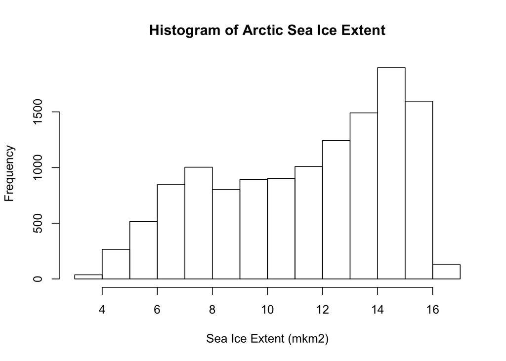

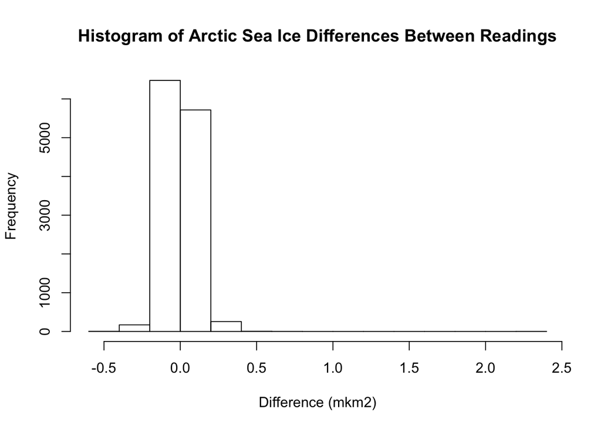

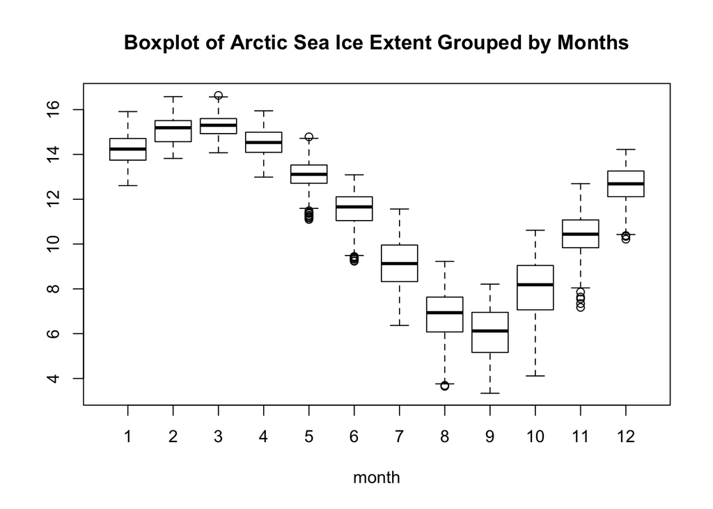

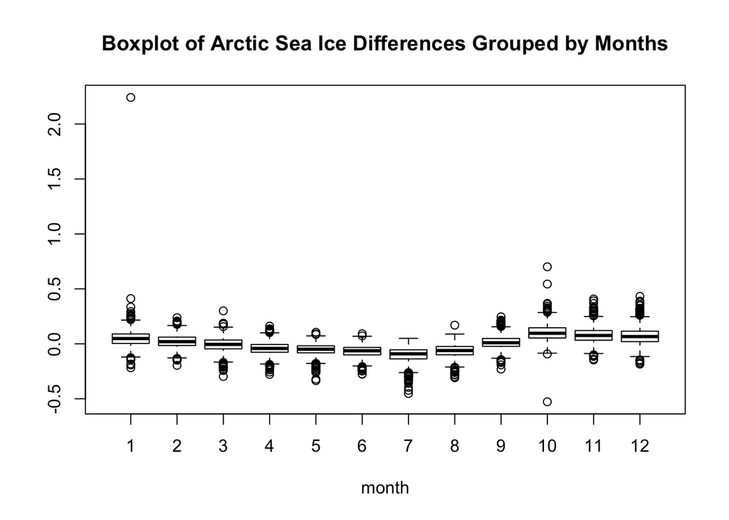

Values of sea ice extent are not normally distributed and in fact skewed left, again supporting ice loss over time. Differences between readings shows an unusual distribution mostly centered around near zero. There is one extreme outlier in the difference (diff) dataset of +2.242. Most increases (or decreasaes) are less than 0.5, so this point is unusual and occured in the January readings of 1988.

Not surprisingly, Arctic sea ice is at it’s greatest extent at or near the Northern Hemisphere’s winter months (January through April) and at it’s lowest during the summer (especially August and September). On average, by October, sea ice is already expanding again from it’s lowest extent.

# Outlier

To address this single, clear outlier, which is the result of a long lapse between readings, the average difference in sea ice extent change was calculated. This was accomplished by dividing the sea ice extent difference by the number of days between observations, thus normalizing the observations regardless of the time passing between two measurements.

# Further graphical analysis

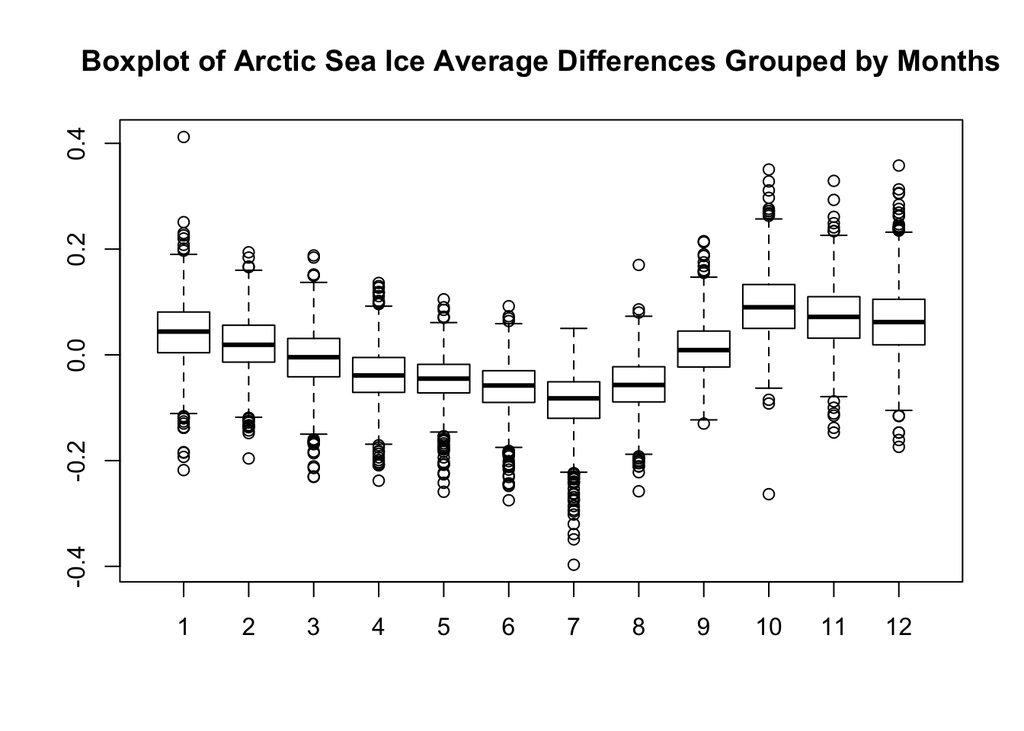

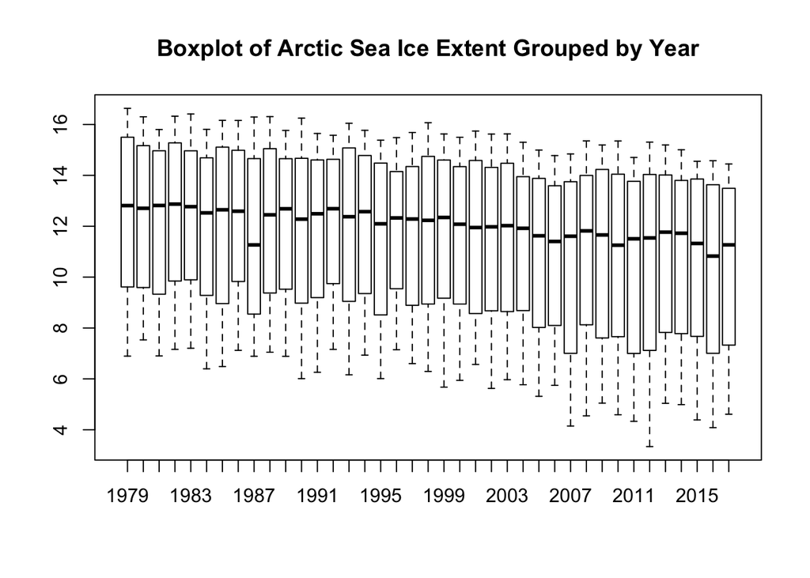

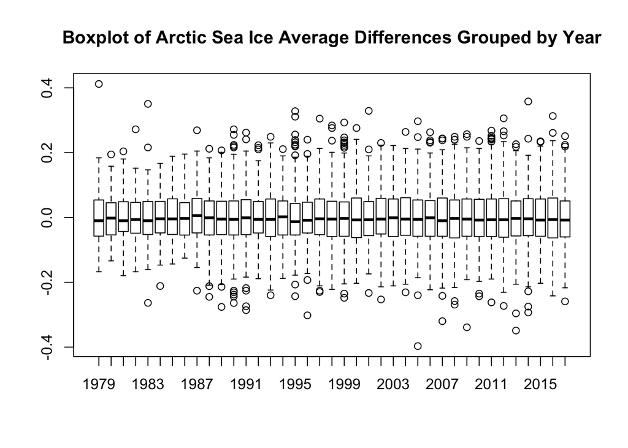

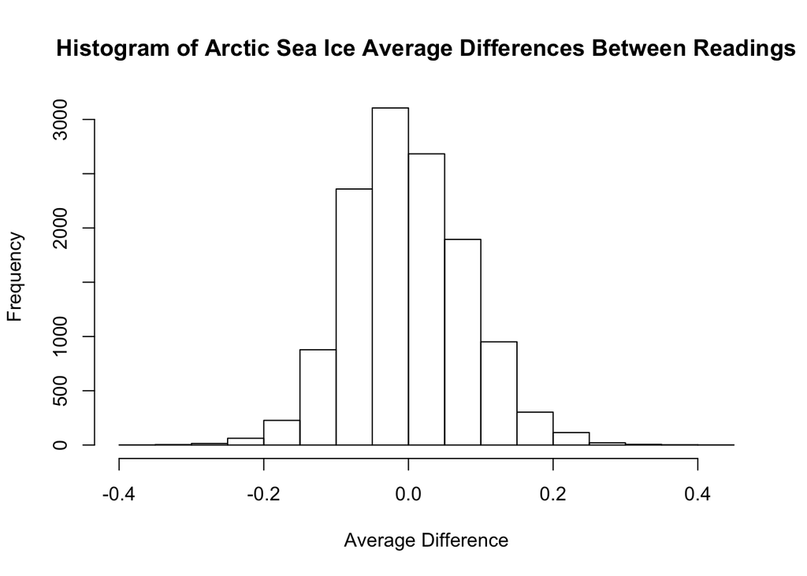

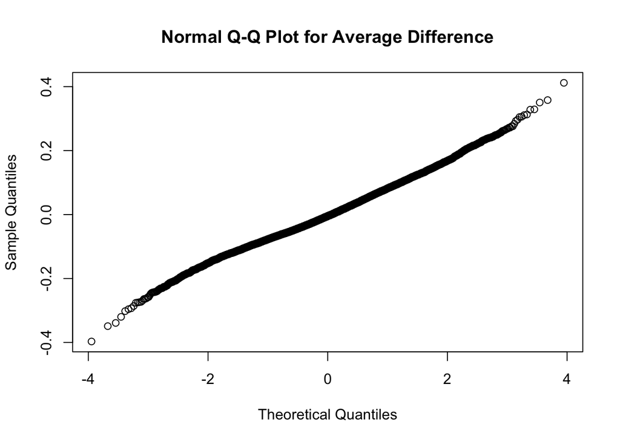

```
##       Min.    1st Qu.     Median       Mean    3rd Qu.       Max.
## -0.3970000 -0.0560000 -0.0050000 -0.0000409  0.0536905  0.4120000
```

These graphics and the statistics show a few things. First, as expected, sea ice extent difference is variable month to month, but year over year, appears to show a fairly stable trend. The historgram and quanitile-quantile plot of average difference also appears fairly normal. As the overall trend of sea ice extent appears to be receding over time, it would seem that the average change in extent, in aggregate, should also be skewed toward net ice loss (negative numbers), and it is, but only slightly. This compounding effect of year over year net loss and few, if any, years of ice building, has resulted in the trend over time of decreasing ice cover in the Arctic.

# Time Series Analysis and Forecasting

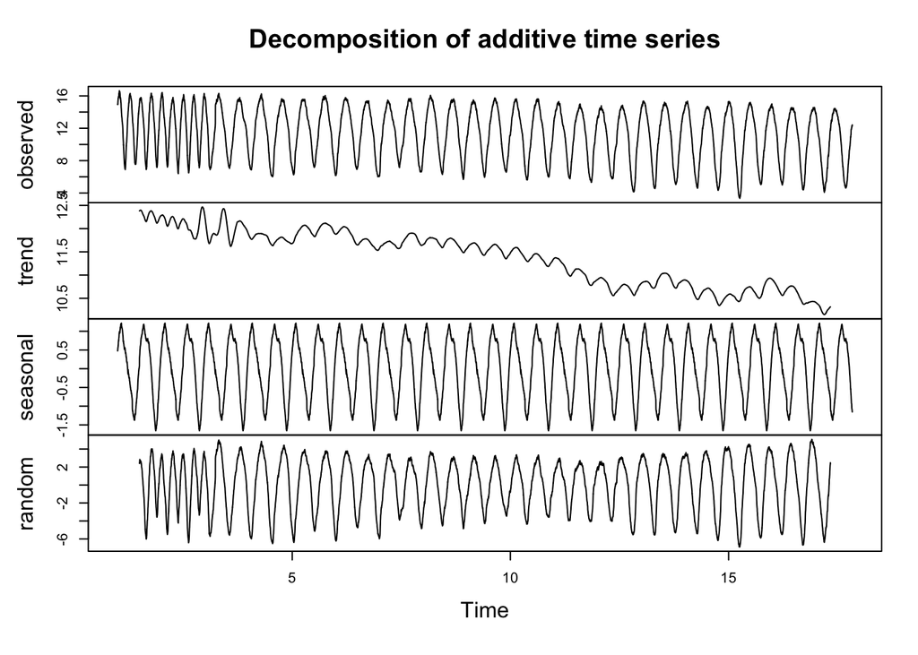

Decomposition of the time series into components shows the overall downward trend and strong seasonality associated with winter and summer months.

# Final Conclusions